# Fibrex Microbiome description

### ORDER

#### COUNTS

At order level the microbiome counts are as follows for each group and timepoint

```r
# load data
load("R_objects/Agglomerated_Cecum.RData")
params <- readRDS("R_objects/params_description.RDS")

# Remove samples with missing data
phy.use <- prune_samples(sample_names(phy.or)[!is.na(sample_data(phy.or)[,params$group_var]) & !is.na(sample_data(phy.or)[,params$time_var])], phy.or)


# Transform data
phy.rel <- transform_sample_counts(phy.use, fun = function(x) x/sum(x)*100)
dat <- psmelt(phy.rel)

# summarise per sample
sumsample <-
  dat %>%
  filter(Abundance > 0) %>%
  group_by(Sample, .data[[params$group_var]], .data[[params$time_var]]) %>%
  summarise(pct_0 = n(),
            pct_0.1 = sum(Abundance < 0.1),
            pct_0_1 = sum(Abundance >= 0.1 & Abundance < 1),
            pct_1_10 = sum(Abundance >= 1 & Abundance < 10),
            pct_10 = sum(Abundance > 10)) %>%
  pivot_longer(starts_with("pct"),
               names_to = c("Cutoff"),
               values_to = "Count") %>%
  group_by(Cutoff, .data[[params$group_var]], .data[[params$time_var]]) %>%
  summarise(mean = round(mean(Count),2),
            sd = round(sd(Count),2))

# summarise total
sumall <- dat %>%
  filter(Abundance > 0) %>%
  group_by(OTU, .data[[params$group_var]], .data[[params$time_var]]) %>%
  summarise(Abundance = mean(Abundance)) %>%
  group_by(.data[[params$group_var]], .data[[params$time_var]]) %>%
  summarise(pct_0 = n(),
            pct_0.1 = sum(Abundance < 0.1),
            pct_0_1 = sum(Abundance >= 0.1 & Abundance < 1),
            pct_1_10 = sum(Abundance >= 1 & Abundance < 10),
            pct_10 = sum(Abundance > 10)) %>%
  pivot_longer(starts_with("pct"),
               names_to = c("Cutoff"),
               values_to = "n")

# Combine
output <- full_join(sumall, sumsample) %>%
  pivot_wider(id_cols = c(Cutoff, .data[[params$time_var]]),
              names_from = .data[[params$group_var]],
              values_from = c(n, mean, sd),
              names_vary = "slowest") %>%
  mutate(Cutoff=factor(Cutoff))


levels(output$Cutoff) <- c("All", "n < 0.1%", "0.1% < n < 1.0%", "1.0% < n < 10%", "10%  < n")

# Create output table
kable(output, row.names = F,digits = 2, caption = 'Count of orders in general and per sample',align = "r") %>%
  kable_classic(full_width = F, position = "left")
```

Count of orders in general and per sample

| Cutoff | day | n_HF_CTRL | mean_HF_CTRL | sd_HF_CTRL | n_HF_PFOS | mean_HF_PFOS | sd_HF_PFOS | n_LF_CTRL | mean_LF_CTRL | sd_LF_CTRL | n_LF_PFOS | mean_LF_PFOS | sd_LF_PFOS |
| --- | --- | --- | --- | --- | --- | --- | --- | --- | --- | --- | --- | --- | --- |
| All | d08 | 21 | 16.83 | 1.60 | 21 | 16.67 | 1.86 | 21 | 17.60 | 1.14 | 22 | 18.67 | 1.63 |
| n < 0.1% | d08 | 11 | 8.17 | 1.47 | 11 | 9.17 | 1.17 | 9 | 8.00 | 1.87 | 12 | 10.33 | 2.16 |
| 0.1% < n < 1.0% | d08 | 5 | 4.67 | 1.03 | 6 | 4.17 | 0.98 | 6 | 3.80 | 1.79 | 4 | 4.17 | 2.32 |
| 1.0% < n < 10% | d08 | 2 | 1.33 | 0.82 | 1 | 1.00 | 1.10 | 4 | 3.60 | 0.89 | 4 | 2.17 | 1.47 |
| 10% < n | d08 | 3 | 2.67 | 0.52 | 3 | 2.33 | 0.82 | 2 | 2.20 | 0.45 | 2 | 2.00 | 0.00 |
| All | d21 | 22 | 18.67 | 1.37 | 24 | 18.17 | 2.23 | 20 | 17.00 | 2.00 | 22 | 18.50 | 1.64 |
| n < 0.1% | d21 | 14 | 10.50 | 2.07 | 16 | 11.17 | 2.23 | 9 | 7.83 | 2.93 | 11 | 7.50 | 3.27 |
| 0.1% < n < 1.0% | d21 | 4 | 3.83 | 0.98 | 4 | 3.33 | 1.51 | 7 | 5.33 | 1.51 | 5 | 6.50 | 2.51 |
| 1.0% < n < 10% | d21 | 2 | 2.00 | 0.89 | 2 | 1.67 | 1.03 | 2 | 1.83 | 0.75 | 4 | 2.67 | 1.75 |
| 10% < n | d21 | 2 | 2.33 | 0.52 | 2 | 2.00 | 0.89 | 2 | 2.00 | 0.00 | 2 | 1.83 | 0.41 |

#### PLOTS

To improve the interpretation of the compositional plots I will pretreat the data with three steps:

1. Filter taxa by average abundance (minimum 1 %) and rank (max 19 features + “Others”)
2. Sort the plotted taxa by full phylogeny
3. Change taxa names in plot to a letter and include table of full taxonomy

Following this I will incorporate both time_var and subject_var in the plot

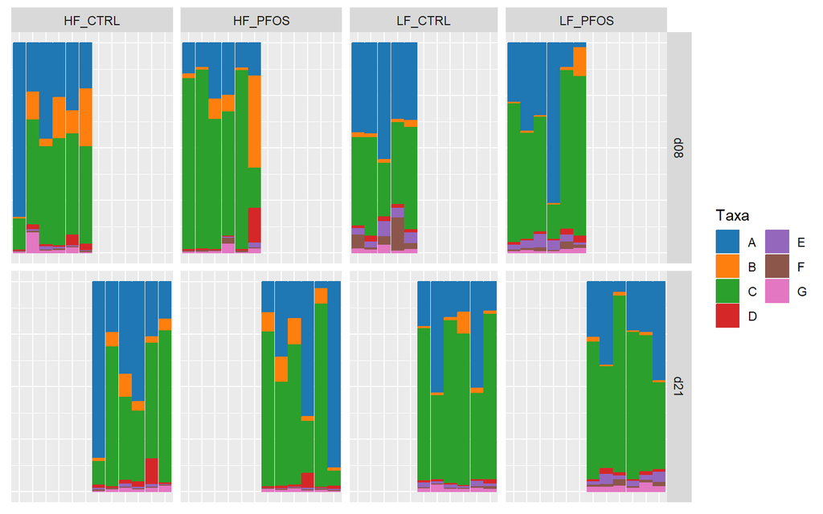

```r
# Filter by abundance, then rank
phy.top <- filter_abundance(phy.rel, group = params$group_var,includes = "any") %>% filter_rank(group = params$time_var,min.rank = 6,includes = "any")

#Melt data
dat <- suppressWarnings(psmelt(phy.top))

# Prevent duplicate column names
colnames(dat)[colnames(dat) %in% c("Taxa","SampleID")] <- paste(colnames(dat)[colnames(dat) %in% c("Taxa","SampleID")], "old", sep = "_")

# Rename relevant columns
colnames(dat)[c(1,4)] <- c("Taxa","SampleID")

# Sort taxa
dat.sort <- sort_taxa(dat)

# rename taxa
levels(dat.sort$Taxa) <- LETTERS[seq(length(levels(dat.sort$Taxa)))]

# ensure that the variables are factors
dat.sort[,params$time_var] <- factor(dat.sort[,params$time_var])
dat.sort[,params$subject_var] <- factor(dat.sort[,params$subject_var])
dat.sort[,params$group_var] <- factor(dat.sort[,params$group_var])

# Create plot
p <- ggplot(dat.sort, aes(x = .data[[params$subject_var]],
                          y = Abundance,
                          fill = Taxa,
                          color = Taxa)) +
  geom_col() +
  xlab("") +
  facet_grid(get(params$time_var) ~ get(params$group_var),
             space = "free_x",scales = "free_x") +
  ggsci::scale_color_d3(palette = "category20") +
  ggsci::scale_fill_d3(palette = "category20") +
  guides(fill=guide_legend(ncol=2), color=guide_legend(ncol=2)) +
  clean_theme()
p
```

```r
# print tax table
tax <- dat.sort %>% distinct(Taxa,.keep_all = T) %>% select(Taxa, Kingdom, Phylum, Class, Order) %>% arrange(Taxa)

kable(tax,digits = 2,caption = paste("Taxa plotted", sep = " ")) %>%
  kable_classic(full_width = F, position = "left")
```

Taxa plotted

| Taxa | Kingdom | Phylum | Class | Order |
| --- | --- | --- | --- | --- |
| A | Bacteria | Bacteroidetes | Bacteroidia | Bacteroidales |
| B | Bacteria | Firmicutes | Bacilli | Lactobacillales |
| C | Bacteria | Firmicutes | Clostridia | Clostridiales |
| D | Bacteria | Firmicutes | Erysipelotrichia | Erysipelotrichales |
| E | Bacteria | Proteobacteria | Deltaproteobacteria | Desulfovibrionales |
| F | Bacteria | Proteobacteria | Gammaproteobacteria | Enterobacterales |
| G | Others | Others | Others | Others |

```r
# clear the environment and release memory
rm(list = ls(all.names = TRUE))
invisible(gc())
```

### FAMILY

#### COUNTS

At family level the microbiome counts are as follows for each group and timepoint

```r
# load data
load("R_objects/Agglomerated_Cecum.RData")
params <- readRDS("R_objects/params_description.RDS")

# Remove samples with missing data
phy.use <- prune_samples(sample_names(phy.fa)[!is.na(sample_data(phy.fa)[,params$group_var]) & !is.na(sample_data(phy.fa)[,params$time_var])], phy.fa)

# Transform data
phy.rel <- transform_sample_counts(phy.use, fun = function(x) x/sum(x)*100)
dat <- psmelt(phy.rel)

# summarise per sample
sumsample <-
  dat %>%
  filter(Abundance > 0) %>%
  group_by(Sample, .data[[params$group_var]], .data[[params$time_var]]) %>%
  summarise(pct_0 = n(),
            pct_0.1 = sum(Abundance < 0.1),
            pct_0_1 = sum(Abundance >= 0.1 & Abundance < 1),
            pct_1_10 = sum(Abundance >= 1 & Abundance < 10),
            pct_10 = sum(Abundance > 10)) %>%
  pivot_longer(starts_with("pct"),
               names_to = c("Cutoff"),
               values_to = "Count") %>%
  group_by(Cutoff, .data[[params$group_var]], .data[[params$time_var]]) %>%
  summarise(mean = round(mean(Count),2),
            sd = round(sd(Count),2))

# summarise total
sumall <- dat %>%
  filter(Abundance > 0) %>%
  group_by(OTU, .data[[params$group_var]], .data[[params$time_var]]) %>%
  summarise(Abundance = mean(Abundance)) %>%
  group_by(.data[[params$group_var]], .data[[params$time_var]]) %>%
  summarise(pct_0 = n(),
            pct_0.1 = sum(Abundance < 0.1),
            pct_0_1 = sum(Abundance >= 0.1 & Abundance < 1),
            pct_1_10 = sum(Abundance >= 1 & Abundance < 10),
            pct_10 = sum(Abundance > 10)) %>%
  pivot_longer(starts_with("pct"),
               names_to = c("Cutoff"),
               values_to = "n")

# Combine
output <- full_join(sumall, sumsample) %>%
  pivot_wider(id_cols = c(Cutoff, .data[[params$time_var]]),
              names_from = .data[[params$group_var]],
              values_from = c(n, mean, sd),
              names_vary = "slowest") %>%
  mutate(Cutoff=factor(Cutoff))


levels(output$Cutoff) <- c("All", "n < 0.1%", "0.1% < n < 1.0%", "1.0% < n < 10%", "10%  < n")

# Create output table
kable(output, row.names = F,digits = 2, caption = 'Count of families in general and per sample',align = "r") %>%
  kable_classic(full_width = F, position = "left")
```

Count of families in general and per sample

| Cutoff | day | n_HF_CTRL | mean_HF_CTRL | sd_HF_CTRL | n_HF_PFOS | mean_HF_PFOS | sd_HF_PFOS | n_LF_CTRL | mean_LF_CTRL | sd_LF_CTRL | n_LF_PFOS | mean_LF_PFOS | sd_LF_PFOS |
| --- | --- | --- | --- | --- | --- | --- | --- | --- | --- | --- | --- | --- | --- |
| All | d08 | 45 | 34.00 | 3.03 | 44 | 34.33 | 3.98 | 46 | 38.40 | 2.51 | 44 | 37.83 | 2.99 |
| n < 0.1% | d08 | 24 | 15.83 | 3.60 | 23 | 16.50 | 3.33 | 22 | 17.40 | 3.91 | 22 | 18.67 | 3.01 |
| 0.1% < n < 1.0% | d08 | 9 | 9.67 | 2.07 | 8 | 9.00 | 2.19 | 9 | 7.40 | 2.19 | 6 | 8.33 | 1.21 |
| 1.0% < n < 10% | d08 | 8 | 6.17 | 2.32 | 10 | 6.50 | 2.07 | 11 | 10.00 | 1.41 | 12 | 7.50 | 1.52 |
| 10% < n | d08 | 4 | 2.33 | 0.82 | 3 | 2.33 | 0.82 | 4 | 3.60 | 0.55 | 4 | 3.33 | 1.03 |
| All | d21 | 46 | 36.67 | 2.42 | 47 | 35.67 | 2.66 | 44 | 35.83 | 4.17 | 47 | 39.83 | 2.64 |
| n < 0.1% | d21 | 26 | 17.67 | 2.50 | 28 | 18.67 | 3.72 | 21 | 14.67 | 4.55 | 23 | 16.00 | 3.52 |
| 0.1% < n < 1.0% | d21 | 8 | 9.00 | 2.10 | 9 | 9.17 | 2.23 | 13 | 10.83 | 1.47 | 8 | 11.33 | 1.75 |
| 1.0% < n < 10% | d21 | 9 | 7.50 | 2.35 | 8 | 5.33 | 1.37 | 6 | 7.33 | 1.51 | 13 | 9.33 | 1.21 |
| 10% < n | d21 | 3 | 2.50 | 1.05 | 2 | 2.50 | 1.38 | 4 | 3.00 | 1.41 | 3 | 3.17 | 0.41 |

#### PLOTS

To improve the interpretation of the compositional plots I will pretreat the data with three steps:

1. Filter taxa by average abundance (minimum 1 %) and rank (max 19 features + “Others”)
2. Sort the plotted taxa by full phylogeny
3. Change taxa names in plot to a letter and include table of full taxonomy

Following this I will incorporate both time_var and subject_var in the plot

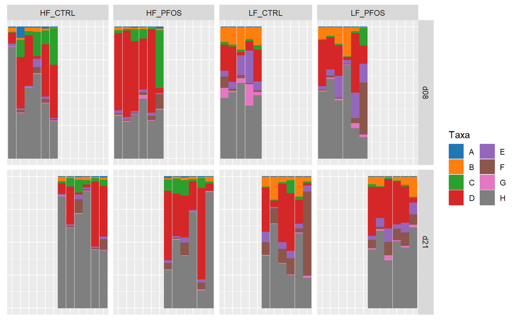

```r
# Filter by abundance, then rank
phy.top <- filter_abundance(phy.rel, group = params$group_var,includes = "any") %>% filter_rank(group = params$time_var, min.rank = 6, includes = "any")

#Melt data
dat <- suppressWarnings(psmelt(phy.top))

# Prevent duplicate column names
colnames(dat)[colnames(dat) %in% c("Taxa","SampleID")] <- paste(colnames(dat)[colnames(dat) %in% c("Taxa","SampleID")], "old", sep = "_")

# Rename relevant columns
colnames(dat)[c(1,4)] <- c("Taxa","SampleID")

# Sort taxa
dat.sort <- sort_taxa(dat)

# rename taxa
levels(dat.sort$Taxa) <- LETTERS[seq(length(levels(dat.sort$Taxa)))]

# ensure that the variables are factors
dat.sort[,params$time_var] <- factor(dat.sort[,params$time_var])
dat.sort[,params$subject_var] <- factor(dat.sort[,params$subject_var])
dat.sort[,params$group_var] <- factor(dat.sort[,params$group_var])

# Create plot
p <- ggplot(dat.sort, aes(x = .data[[params$subject_var]],
                          y = Abundance,
                          fill = Taxa,
                          color = Taxa)) +
  geom_col() +
  xlab("") +
  facet_grid(get(params$time_var) ~ get(params$group_var),
             space = "free_x",scales = "free_x") +
  ggsci::scale_color_d3(palette = "category20") +
  ggsci::scale_fill_d3(palette = "category20") +
  guides(fill=guide_legend(ncol=2), color=guide_legend(ncol=2)) +
  clean_theme()
p
```

```r
# print tax table
tax <- dat.sort %>% distinct(Taxa,.keep_all = T) %>% select(Taxa, Kingdom, Phylum, Class, Order,Family) %>% arrange(Taxa)

kable(tax,digits = 2,caption = paste("Taxa plotted", sep = " ")) %>%
  kable_classic(full_width = F, position = "left")
```

Taxa plotted

| Taxa | Kingdom | Phylum | Class | Order | Family |
| --- | --- | --- | --- | --- | --- |
| A | Bacteria | Actinobacteria | Actinobacteria | Bifidobacteriales | Bifidobacteriaceae |
| B | Bacteria | Bacteroidetes | Bacteroidia | Bacteroidales | Porphyromonadaceae |
| C | Bacteria | Firmicutes | Bacilli | Lactobacillales | Lactobacillaceae |
| D | Bacteria | Firmicutes | Clostridia | Clostridiales | Lachnospiraceae |
| E | Bacteria | Firmicutes | Clostridia | Clostridiales | Order_Clostridiales |
| F | Bacteria | Firmicutes | Clostridia | Clostridiales | Peptostreptococcaceae |
| G | Bacteria | Proteobacteria | Gammaproteobacteria | Enterobacterales | Enterobacteriaceae |
| H | Others | Others | Others | Others | Others |

```r
# clear the environment and release memory
rm(list = ls(all.names = TRUE))
invisible(gc())
```

### GENUS

#### COUNTS

At genus level the microbiome counts are as follows for each group and timepoint

```r
# load data
load("R_objects/Agglomerated_Cecum.RData")
params <- readRDS("R_objects/params_description.RDS")

# Remove samples with missing data
phy.use <- prune_samples(sample_names(phy.ge)[!is.na(sample_data(phy.ge)[,params$group_var]) & !is.na(sample_data(phy.ge)[,params$time_var])], phy.ge)

# Transform data
phy.rel <- transform_sample_counts(phy.use, fun = function(x) x/sum(x)*100)
dat <- psmelt(phy.rel)

# summarise per sample
sumsample <-
  dat %>%
  filter(Abundance > 0) %>%
  group_by(Sample, .data[[params$group_var]], .data[[params$time_var]]) %>%
  summarise(pct_0 = n(),
            pct_0.1 = sum(Abundance < 0.1),
            pct_0_1 = sum(Abundance >= 0.1 & Abundance < 1),
            pct_1_10 = sum(Abundance >= 1 & Abundance < 10),
            pct_10 = sum(Abundance > 10)) %>%
  pivot_longer(starts_with("pct"),
               names_to = c("Cutoff"),
               values_to = "Count") %>%
  group_by(Cutoff, .data[[params$group_var]], .data[[params$time_var]]) %>%
  summarise(mean = round(mean(Count),2),
            sd = round(sd(Count),2))

# summarise total
sumall <- dat %>%
  filter(Abundance > 0) %>%
  group_by(OTU, .data[[params$group_var]], .data[[params$time_var]]) %>%
  summarise(Abundance = mean(Abundance)) %>%
  group_by(.data[[params$group_var]], .data[[params$time_var]]) %>%
  summarise(pct_0 = n(),
            pct_0.1 = sum(Abundance < 0.1),
            pct_0_1 = sum(Abundance >= 0.1 & Abundance < 1),
            pct_1_10 = sum(Abundance >= 1 & Abundance < 10),
            pct_10 = sum(Abundance > 10)) %>%
  pivot_longer(starts_with("pct"),
               names_to = c("Cutoff"),
               values_to = "n")

# Combine
output <- full_join(sumall, sumsample) %>%
  pivot_wider(id_cols = c(Cutoff, .data[[params$time_var]]),
              names_from = .data[[params$group_var]],
              values_from = c(n, mean, sd),
              names_vary = "slowest") %>%
  mutate(Cutoff=factor(Cutoff))


levels(output$Cutoff) <- c("All", "n < 0.1%", "0.1% < n < 1.0%", "1.0% < n < 10%", "10%  < n")

# Create output table
kable(output, row.names = F,digits = 2, caption = 'Count of genera in general and per sample',align = "r") %>%
  kable_classic(full_width = F, position = "left")
```

Count of genera in general and per sample

| Cutoff | day | n_HF_CTRL | mean_HF_CTRL | sd_HF_CTRL | n_HF_PFOS | mean_HF_PFOS | sd_HF_PFOS | n_LF_CTRL | mean_LF_CTRL | sd_LF_CTRL | n_LF_PFOS | mean_LF_PFOS | sd_LF_PFOS |
| --- | --- | --- | --- | --- | --- | --- | --- | --- | --- | --- | --- | --- | --- |
| All | d08 | 109 | 75.83 | 8.98 | 105 | 74.17 | 9.77 | 105 | 82.00 | 8.72 | 108 | 84.83 | 10.46 |
| n < 0.1% | d08 | 58 | 42.17 | 7.68 | 62 | 42.17 | 6.85 | 60 | 44.60 | 8.88 | 67 | 51.67 | 8.87 |
| 0.1% < n < 1.0% | d08 | 28 | 20.17 | 3.82 | 24 | 19.83 | 3.54 | 25 | 20.80 | 1.48 | 20 | 17.83 | 2.32 |
| 1.0% < n < 10% | d08 | 20 | 11.33 | 3.33 | 17 | 10.50 | 4.59 | 16 | 13.60 | 1.67 | 19 | 12.50 | 1.76 |
| 10% < n | d08 | 3 | 2.17 | 0.98 | 2 | 1.67 | 1.21 | 4 | 3.00 | 0.00 | 2 | 2.83 | 0.75 |
| All | d21 | 108 | 78.00 | 9.17 | 107 | 78.17 | 7.36 | 96 | 74.83 | 9.33 | 109 | 85.67 | 8.48 |
| n < 0.1% | d21 | 62 | 43.00 | 6.78 | 64 | 46.67 | 5.13 | 54 | 39.83 | 9.58 | 64 | 44.33 | 8.50 |
| 0.1% < n < 1.0% | d21 | 24 | 20.00 | 4.00 | 26 | 20.50 | 3.02 | 28 | 21.67 | 3.98 | 24 | 24.00 | 2.45 |
| 1.0% < n < 10% | d21 | 21 | 12.67 | 4.76 | 15 | 8.83 | 3.31 | 12 | 10.67 | 2.73 | 20 | 15.17 | 2.93 |
| 10% < n | d21 | 1 | 2.33 | 1.37 | 2 | 2.17 | 1.17 | 2 | 2.67 | 1.37 | 1 | 2.17 | 1.17 |

#### PLOTS

To improve the interpretation of the compositional plots I will pretreat the data with three steps:

1. Filter taxa by average abundance (minimum 1 %) and rank (max 19 features + “Others”)
2. Sort the plotted taxa by full phylogeny
3. Change taxa names in plot to a letter and include table of full taxonomy

Following this I will incorporate both time_var and subject_var in the plot

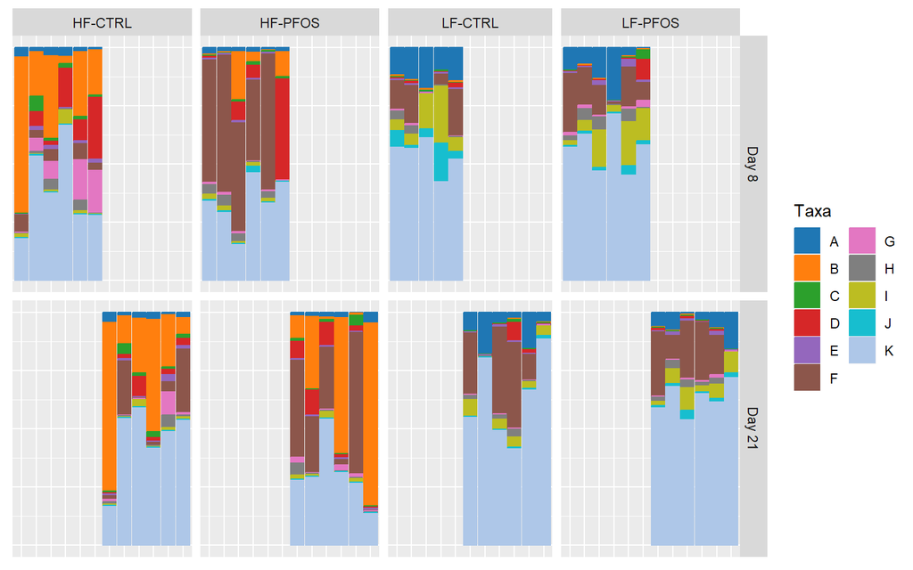

```r
# Filter by abundance, then rank
phy.top <- filter_abundance(phy.rel, group = params$group_var,includes = "any") %>% filter_rank(group = params$time_var, min.rank = 6, includes = "any")

#Melt data
dat <- suppressWarnings(psmelt(phy.top))

# Prevent duplicate column names
colnames(dat)[colnames(dat) %in% c("Taxa","SampleID")] <- paste(colnames(dat)[colnames(dat) %in% c("Taxa","SampleID")], "old", sep = "_")

# Rename relevant columns
colnames(dat)[c(1,4)] <- c("Taxa","SampleID")

# Sort taxa
dat.sort <- sort_taxa(dat)

# rename taxa
levels(dat.sort$Taxa) <- LETTERS[seq(length(levels(dat.sort$Taxa)))]

# ensure that the variables are factors
dat.sort[,params$time_var] <- factor(dat.sort[,params$time_var])
dat.sort[,params$subject_var] <- factor(dat.sort[,params$subject_var])
dat.sort[,params$group_var] <- factor(dat.sort[,params$group_var])

# Create plot
p <- ggplot(dat.sort, aes(x = .data[[params$subject_var]],
                          y = Abundance,
                          fill = Taxa,
                          color = Taxa)) +
  geom_col() +
  xlab("") +
  facet_grid(day ~ feed_treat,
             space = "free_x",scales = "free_x",
             labeller = labeller(day = c("d0" = "Day 0", "d08" = "Day 8", "d12" = "Day 12", "d16" = "Day 16", "d20" = "Day 20", "d21" = "Day 21"),
                                 feed_treat = c("HF_CTRL" = "HF-CTRL","HF_PFOS"="HF-PFOS","LF_CTRL"="LF-CTRL","LF_PFOS"="LF-PFOS"))) +
  ggsci::scale_color_d3(palette = "category20") +
  ggsci::scale_fill_d3(palette = "category20") +
  guides(fill=guide_legend(ncol=2), color=guide_legend(ncol=2)) +
  clean_theme()
p
```

```r
p.fig <- p + theme_pubr(legend = "right", border = TRUE) + theme(axis.text.x = element_text(angle = 90))

if (!file.exists(paste0("plots/relative_abundance"))) dir.create(file.path(getwd(), paste0("plots/relative_abundance")))
ggsave(filename = "plots/figures/Genus_abundance.png", plot = p.fig, device = "png", units = "mm", width = 300, height = 185, dpi = 300)
ggsave(filename = "plots/figures/Genus_abundance.pdf", plot = p.fig, device = "pdf", units = "mm", width = 300, height = 185, dpi = 300)

# print tax table
tax <- dat.sort %>% distinct(Taxa,.keep_all = T) %>% select(Taxa, Kingdom, Phylum, Class, Order,Family,Genus)  %>% arrange(Taxa)

kable(tax,digits = 2,caption = paste("Taxa plotted", sep = " ")) %>%
  kable_classic(full_width = F, position = "left")
```

Taxa plotted

| Taxa | Kingdom | Phylum | Class | Order | Family | Genus |
| --- | --- | --- | --- | --- | --- | --- |
| A | Bacteria | Bacteroidetes | Bacteroidia | Bacteroidales | Porphyromonadaceae | Parabacteroides |
| B | Bacteria | Bacteroidetes | Bacteroidia | Bacteroidales | Prevotellaceae | Prevotella |
| C | Bacteria | Firmicutes | Bacilli | Lactobacillales | Lactobacillaceae | Lactobacillus |
| D | Bacteria | Firmicutes | Bacilli | Lactobacillales | Lactobacillaceae | Ligilactobacillus |
| E | Bacteria | Firmicutes | Clostridia | Clostridiales | Lachnospiraceae | Faecalicatena |
| F | Bacteria | Firmicutes | Clostridia | Clostridiales | Lachnospiraceae | Family_Lachnospiraceae |
| G | Bacteria | Firmicutes | Clostridia | Clostridiales | Lachnospiraceae | Roseburia |
| H | Bacteria | Firmicutes | Clostridia | Clostridiales | Lachnospiraceae | Sellimonas |
| I | Bacteria | Firmicutes | Clostridia | Clostridiales | Order_Clostridiales | Order_Clostridiales |
| J | Bacteria | Proteobacteria | Gammaproteobacteria | Enterobacterales | Enterobacteriaceae | Escherichia/Shigella |
| K | Others | Others | Others | Others | Others | Others |

```r
# clear the environment and release memory
rm(list = ls(all.names = TRUE))
invisible(gc())
```

### SPECIES

#### COUNTS

At species level the microbiome counts are as follows for each group and timepoint

```r
# load data
load("R_objects/Agglomerated_Cecum.RData")
params <- readRDS("R_objects/params_description.RDS")

# Remove samples with missing data
phy.use <- prune_samples(sample_names(phy.sp)[!is.na(sample_data(phy.sp)[,params$group_var]) & !is.na(sample_data(phy.sp)[,params$time_var])], phy.sp)

# Transform data
phy.rel <- transform_sample_counts(phy.use, fun = function(x) x/sum(x)*100)
dat <- psmelt(phy.rel)

# summarise per sample
sumsample <-
  dat %>%
  filter(Abundance > 0) %>%
  group_by(Sample, .data[[params$group_var]], .data[[params$time_var]]) %>%
  summarise(pct_0 = n(),
            pct_0.1 = sum(Abundance < 0.1),
            pct_0_1 = sum(Abundance >= 0.1 & Abundance < 1),
            pct_1_10 = sum(Abundance >= 1 & Abundance < 10),
            pct_10 = sum(Abundance > 10)) %>%
  pivot_longer(starts_with("pct"),
               names_to = c("Cutoff"),
               values_to = "Count") %>%
  group_by(Cutoff, .data[[params$group_var]], .data[[params$time_var]]) %>%
  summarise(mean = round(mean(Count),2),
            sd = round(sd(Count),2))

# summarise total
sumall <- dat %>%
  filter(Abundance > 0) %>%
  group_by(OTU, .data[[params$group_var]], .data[[params$time_var]]) %>%
  summarise(Abundance = mean(Abundance)) %>%
  group_by(.data[[params$group_var]], .data[[params$time_var]]) %>%
  summarise(pct_0 = n(),
            pct_0.1 = sum(Abundance < 0.1),
            pct_0_1 = sum(Abundance >= 0.1 & Abundance < 1),
            pct_1_10 = sum(Abundance >= 1 & Abundance < 10),
            pct_10 = sum(Abundance > 10)) %>%
  pivot_longer(starts_with("pct"),
               names_to = c("Cutoff"),
               values_to = "n")

# Combine
output <- full_join(sumall, sumsample) %>%
  pivot_wider(id_cols = c(Cutoff, .data[[params$time_var]]),
              names_from = .data[[params$group_var]],
              values_from = c(n, mean, sd),
              names_vary = "slowest") %>%
  mutate(Cutoff=factor(Cutoff))


levels(output$Cutoff) <- c("All", "n < 0.1%", "0.1% < n < 1.0%", "1.0% < n < 10%", "10%  < n")

# Create output table
kable(output, row.names = F,digits = 2, caption = 'Count of species in general and per sample',align = "r") %>%
  kable_classic(full_width = F, position = "left")
```

Count of species in general and per sample

| Cutoff | day | n_HF_CTRL | mean_HF_CTRL | sd_HF_CTRL | n_HF_PFOS | mean_HF_PFOS | sd_HF_PFOS | n_LF_CTRL | mean_LF_CTRL | sd_LF_CTRL | n_LF_PFOS | mean_LF_PFOS | sd_LF_PFOS |
| --- | --- | --- | --- | --- | --- | --- | --- | --- | --- | --- | --- | --- | --- |
| All | d08 | 139 | 94.50 | 12.06 | 139 | 92.17 | 14.74 | 140 | 105.00 | 11.92 | 141 | 106.33 | 14.47 |
| n < 0.1% | d08 | 79 | 55.33 | 12.74 | 87 | 54.50 | 11.15 | 86 | 60.60 | 12.84 | 92 | 67.17 | 14.18 |
| 0.1% < n < 1.0% | d08 | 38 | 25.50 | 3.73 | 33 | 25.33 | 4.23 | 32 | 26.20 | 2.59 | 27 | 23.00 | 2.53 |
| 1.0% < n < 10% | d08 | 19 | 11.67 | 3.27 | 17 | 10.67 | 5.47 | 19 | 15.80 | 1.64 | 20 | 13.83 | 2.93 |
| 10% < n | d08 | 3 | 2.00 | 0.63 | 2 | 1.67 | 1.21 | 3 | 2.40 | 0.55 | 2 | 2.33 | 0.82 |
| All | d21 | 135 | 95.67 | 11.15 | 138 | 97.33 | 8.38 | 126 | 93.17 | 11.79 | 148 | 109.83 | 11.70 |
| n < 0.1% | d21 | 77 | 53.50 | 9.89 | 85 | 60.67 | 7.84 | 78 | 53.00 | 11.64 | 98 | 64.17 | 12.66 |
| 0.1% < n < 1.0% | d21 | 37 | 27.83 | 2.93 | 40 | 25.67 | 2.94 | 32 | 25.67 | 3.56 | 26 | 26.83 | 1.72 |
| 1.0% < n < 10% | d21 | 20 | 12.17 | 3.76 | 11 | 8.83 | 3.54 | 14 | 12.17 | 3.13 | 23 | 17.00 | 3.85 |
| 10% < n | d21 | 1 | 2.17 | 1.17 | 2 | 2.17 | 1.17 | 2 | 2.33 | 1.03 | 1 | 1.83 | 1.17 |

#### PLOTS

To improve the interpretation of the compositional plots I will pretreat the data with three steps:

1. Filter taxa by average abundance (minimum 1 %) and rank (max 19 features + “Others”)
2. Sort the plotted taxa by full phylogeny
3. Change taxa names in plot to a letter and include table of full taxonomy

Following this I will incorporate both time_var and subject_var in the plot

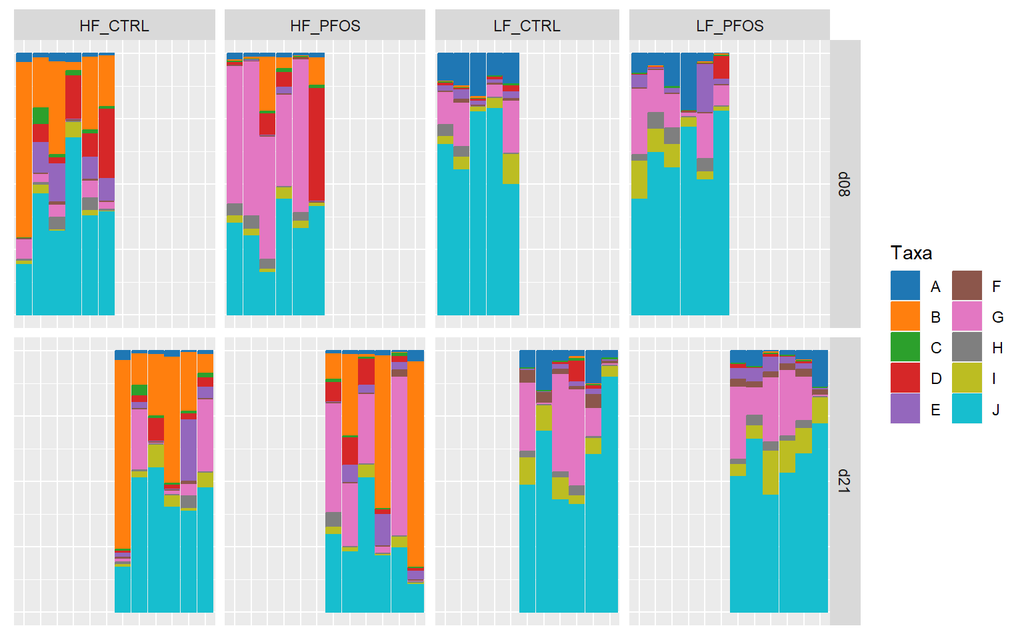

```r
# Filter by abundance, then rank
phy.top <- filter_abundance(phy.rel, group = params$group_var,includes = "any") %>% filter_rank(group = params$time_var, min.rank = 6, includes = "any")

#Melt data
dat <- suppressWarnings(psmelt(phy.top))

# Prevent duplicate column names
colnames(dat)[colnames(dat) %in% c("Taxa","SampleID")] <- paste(colnames(dat)[colnames(dat) %in% c("Taxa","SampleID")], "old", sep = "_")

# Rename relevant columns
colnames(dat)[c(1,4)] <- c("Taxa","SampleID")

# Sort taxa
dat.sort <- sort_taxa(dat)

# rename taxa
levels(dat.sort$Taxa) <- LETTERS[seq(length(levels(dat.sort$Taxa)))]

# ensure that the variables are factors
dat.sort[,params$time_var] <- factor(dat.sort[,params$time_var])
dat.sort[,params$subject_var] <- factor(dat.sort[,params$subject_var])
dat.sort[,params$group_var] <- factor(dat.sort[,params$group_var])

# Create plot
p <- ggplot(dat.sort, aes(x = .data[[params$subject_var]],
                          y = Abundance,
                          fill = Taxa,
                          color = Taxa)) +
  geom_col() +
  xlab("") +
  facet_grid(get(params$time_var) ~ get(params$group_var),
             space = "free_x",scales = "free_x") +
  ggsci::scale_color_d3(palette = "category20") +
  ggsci::scale_fill_d3(palette = "category20") +
  guides(fill=guide_legend(ncol=2), color=guide_legend(ncol=2)) +
  clean_theme()
p
```

```r
# print tax table
tax <- dat.sort %>% distinct(Taxa,.keep_all = T) %>% select(Taxa, Kingdom, Phylum, Class, Order,Family,Genus,Species) %>% arrange(Taxa)

kable(tax,digits = 2,caption = paste("Taxa plotted", sep = " ")) %>%
  kable_classic(full_width = F, position = "left")
```

Taxa plotted

| Taxa | Kingdom | Phylum | Class | Order | Family | Genus | Species |
| --- | --- | --- | --- | --- | --- | --- | --- |
| A | Bacteria | Bacteroidetes | Bacteroidia | Bacteroidales | Porphyromonadaceae | Parabacteroides | distasonis |
| B | Bacteria | Bacteroidetes | Bacteroidia | Bacteroidales | Prevotellaceae | Prevotella | Genus_Prevotella |
| C | Bacteria | Firmicutes | Bacilli | Lactobacillales | Lactobacillaceae | Lactobacillus | intestinalis |
| D | Bacteria | Firmicutes | Bacilli | Lactobacillales | Lactobacillaceae | Ligilactobacillus | Genus_Ligilactobacillus |
| E | Bacteria | Firmicutes | Clostridia | Clostridiales | Lachnospiraceae | Blautia | Genus_Blautia |
| F | Bacteria | Firmicutes | Clostridia | Clostridiales | Lachnospiraceae | Butyrivibrio | Genus_Butyrivibrio |
| G | Bacteria | Firmicutes | Clostridia | Clostridiales | Lachnospiraceae | Family_Lachnospiraceae | Family_Lachnospiraceae |
| H | Bacteria | Firmicutes | Clostridia | Clostridiales | Lachnospiraceae | Sellimonas | Genus_Sellimonas |
| I | Bacteria | Firmicutes | Clostridia | Clostridiales | Ruminococcaceae | Family_Ruminococcaceae | Family_Ruminococcaceae |
| J | Others | Others | Others | Others | Others | Others | Others |

```r
# clear the environment and release memory
rm(list = ls(all.names = TRUE))
invisible(gc())
```

# FINAL COMMENT

This completes the microbiome description.

To begin the statistical analysis of the data you are now ready for the following steps:

| Analysis | Template | Note |
| --- | --- | --- |
| Statistical testing | GMH_test_variables | Statistical test and visualization of alpha diversity and metadata |
| Beta diversity | GMH_beta_diveristy | Statistical test and visualization of beta diversity |
| Differential abundance | GMH_differential_abundance | Test differential abundance of taxa against sample variables |

# SETTINGS

Overview of the parameters and packages that were used for this Rmarkdown.

## PARAMETERS

The following paramenters were set in for this analysis:

```r
params <- readRDS("R_objects/params_description.RDS")


tmp <- unlist(params)
dat <- data.frame(Parameter = names(tmp), Value = unname(tmp))


kbl(dat, row.names = F) %>% kable_classic(lightable_options = "striped")
```

| Parameter | Value |
| --- | --- |
| input | R_objects/Phyloseq.Rdata |
| group_var | feed_treat |
| subject_var | rat_name |
| time_var | day |